# 05_Modelo_Base

### **Decision Tree**

#### **Autores**:

#### - González Díaz, Guillermo

#### - Sebastiani, Carlos

```python
# importamos algunas librerías
import pandas as pd
import numpy as np
from sklearn import tree
from sklearn import metrics
from sklearn.metrics import accuracy_score, confusion_matrix,roc_curve, recall_score,precision_score, precision_recall_curve
import matplotlib.pyplot as plt
import seaborn as sns
import joblib
import scikitplot as skplt
import matplotlib.pyplot as plt
from scikitplot.metrics import plot_lift_curve
from aux_func import print_metrics, matriz_confusion, curva_roc, curva_pr, ganancia, curva_lift, matriz_confusion_optimizada, print_metrics_optimized
```

```python
import warnings
warnings.filterwarnings("ignore")
```

```python
# Cargamos los data sets y los ponemos en el formato correcto
X_train = pd.read_parquet('../PreprocessingSampled2/X_trainSampled2')
X_test = pd.read_parquet('../PreprocessingSampled2/X_test')
y_train= pd.read_parquet('../PreprocessingSampled2/y_trainSampled2')
y_test= pd.read_csv('../PreprocessingSampled2/y_test').set_index('Unnamed: 0')
```

```python
# Cargamos nuestro modelo
filename = '../modelos/decision.sav'
clf = joblib.load(filename)
```

## **No correr la siguiente celda si el modelo se ha cargado correctamente**

```python
# Entrenamos nuestro modelo
clf = tree.DecisionTreeClassifier()
clf = clf.fit(X_train, y_train)
```

```python
y_pred = clf.predict(X_test)
y_pred_proba= clf.predict_proba(X_test)
```

```python
#Guardamos el modelo
#filename = '../modelos/decision.sav'
#joblib.dump(clf, filename)
```

## Métricas

Este ha sido el modelo que ha arrojado peores métricas.

- **Matriz de confusiones** solamente ha acertado un 30 % de los 1s.
- **Curva de ROC** vemos que casi traza una diagonal, lo que es lo peor que puede hacer, puesto que el True Positive Rate y el False Positive rate crecen casi en la misma porporción, lo que demuestra la aleatoriedad de este modelo.
- Mirando la **curva pr** vemos que la precisión, es decir, de los que decimos que son 1s son realmente 1s, va cayendo muy rápidamente a medida que queremos aumentar en recall, es decir, coger más 1s del total de la muestra. No es un buen indicador.
- La **curva de ganancia** , ocurre algo parecido. A medida que aumentamos el tamaño de la muestra, el número de 1s que acierta no crece. Es una línea casi diagonal, lo que nuevamente nos indica que no es un buen modelo.
- Por último, mirando la **curva lift**, vemos que el valor es bajísimo comparado por ejemplo, con Random Forest, que llegaba a 60. Esto quiere decir que el ratio entre 1s acertados y 1s del dataset es realmente bajo.
- **Accuracy** elevado pero un **recall** muy bajo, lo que es indicador que del total de la muestra no detecta muchos accidentes mortales.

```python
print_metrics(y_test,y_pred)
```

```
------------------------------------------
The accuracy score is:  0.956
------------------------------------------
The F1 score is:  0.629
------------------------------------------
The recall is:  0.291
------------------------------------------
The precision score is:  0.132
```

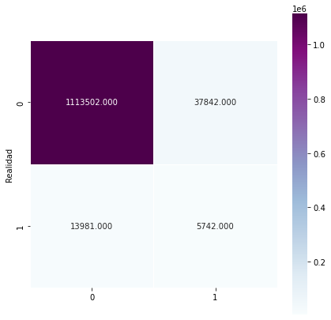

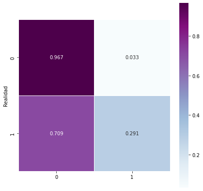

```python
matriz_confusion(y_test, y_pred)
```

```
Best Threshold=1.000000, G-Mean=0.531
```

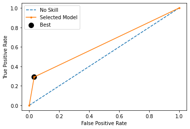

```python
curva_roc(y_test,y_pred_proba)
```

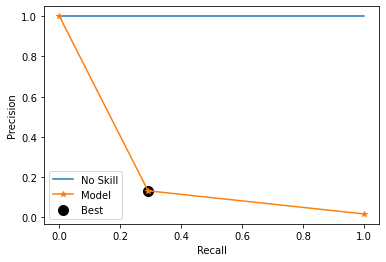

```python
curva_pr(y_test,y_pred_proba)
```

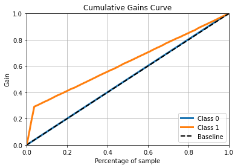

```python
ganancia(clf, y_test, y_pred_proba, X_test)
```

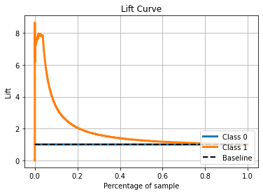

```python
curva_lift(clf, y_test, y_pred_proba, X_test)
```

### Ajustando el threshold: --------------------------------------------------------------------------

Calculamos el umbral a partir del que obtenemos el mejor balance entre True Positive Rate y False Positive Rate. Vemos que este modelo no presenta mejora.

```python
# Nuevas métricas:
print_metrics_optimized(clf, X_test, y_test, y_pred_proba)
```

```
------------------------------------------
The accuracy score is:  0.956
------------------------------------------
The F1 score is:  0.629
------------------------------------------
The recall is:  0.291
------------------------------------------
The precision score is:  0.132
```

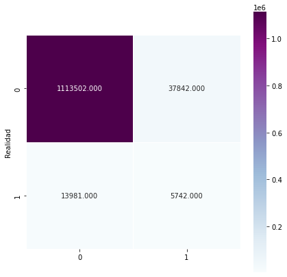

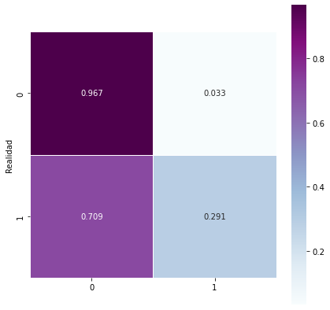

```python
# Nueva matriz de confusiones
matriz_confusion_optimizada(clf, X_test, y_test, y_pred_proba)
```

```python
X_test.shape[0]
```

```
1171067
```